# Reproducible Research 2nd Project

Hsin Chih Chen

2021/9/28

## 1: Data Introduction

This assignment’s data source comes from the storm’s impact towards fatalities, injuries and property damage coming from US National Oceanic and Atmospheric Administration’s storm data. Listing when the storm occurs, and estimating of any fatalities, injuries and property damage.

The data set is located in the [dataset link](https://d396qusza40orc.cloudfront.net/repdata%2Fdata%2FStormData.csv.bz2) to download.

For detailed explanation, please refer to the [documentation link](https://d396qusza40orc.cloudfront.net/repdata%2Fpeer2_doc%2Fpd01016005curr.pdf).

## 2: Data Proceessing

### 2.1: Load the data

Obtain raw data file and extract the data into a data frame.Then convert to a data.table

```r
## load necessary packages
library("data.table")
library("ggplot2")

# Download the
PA02 <- "https://d396qusza40orc.cloudfront.net/repdata%2Fdata%2FStormData.csv.bz2"
download.file(PA02, "StormData.csv.bz2")
stormF <- read.csv("StormData.csv.bz2")

# Converting data.frame to data.table
stormT <- as.data.table(stormF)
```

### 2.2: Verify Data Structure & Column Names

```r
stormT[,c(lapply(.SD, as.numeric, na.rm = FALSE)), .SDcols = c("PROPDMG")]
```

```
##         PROPDMG
##      1:    25.0
##      2:     2.5
##      3:    25.0
##      4:     2.5
##      5:     2.5
##     ---
## 902293:     0.0
## 902294:     0.0
## 902295:     0.0
## 902296:     0.0
## 902297:     0.0
```

```r
stormT[,c(lapply(.SD, as.numeric, na.rm = FALSE)), .SDcols = c("CROPDMG")]
```

```
##         CROPDMG
##      1:       0
##      2:       0
##      3:       0
##      4:       0
##      5:       0
##     ---
## 902293:       0
## 902294:       0
## 902295:       0
## 902296:       0
## 902297:       0
```

```r
str(stormT)
```

```
## Classes 'data.table' and 'data.frame':   902297 obs. of  37 variables:
##  $ STATE__   : num  1 1 1 1 1 1 1 1 1 1 ...
##  $ BGN_DATE  : chr  "4/18/1950 0:00:00" "4/18/1950 0:00:00" "2/20/1951 0:00:00" "6/8/1951 0:00:00" ...
##  $ BGN_TIME  : chr  "0130" "0145" "1600" "0900" ...
##  $ TIME_ZONE : chr  "CST" "CST" "CST" "CST" ...
##  $ COUNTY    : num  97 3 57 89 43 77 9 123 125 57 ...
##  $ COUNTYNAME: chr  "MOBILE" "BALDWIN" "FAYETTE" "MADISON" ...
##  $ STATE     : chr  "AL" "AL" "AL" "AL" ...
##  $ EVTYPE    : chr  "TORNADO" "TORNADO" "TORNADO" "TORNADO" ...
##  $ BGN_RANGE : num  0 0 0 0 0 0 0 0 0 0 ...
##  $ BGN_AZI   : chr  "" "" "" "" ...
##  $ BGN_LOCATI: chr  "" "" "" "" ...
##  $ END_DATE  : chr  "" "" "" "" ...
##  $ END_TIME  : chr  "" "" "" "" ...
##  $ COUNTY_END: num  0 0 0 0 0 0 0 0 0 0 ...
```

[output cut: 24 more lines]

### 2.3: Subset Data

Subset the data only for the interested parameters, in this case will only be occurred event, fatalities, injuries, prop and crop damages

```r
# Find columns to remove
removeCols <- colnames(stormT[, !c("EVTYPE"
              ,"FATALITIES"
              ,"INJURIES"
              ,"PROPDMG"
              ,"PROPDMGEXP"
              ,"CROPDMG"
              ,"CROPDMGEXP")])

# Remove the columns
stormT[, c(removeCols) := NULL]

# Collect where fatalities occurred.
stormT <- stormT[(EVTYPE != "?" &
            (INJURIES > 0 | FATALITIES > 0 | PROPDMG > 0 | CROPDMG > 0)), c("EVTYPE"
              ,"FATALITIES"
              ,"INJURIES"
              ,"PROPDMG"
              ,"PROPDMGEXP"
              ,"CROPDMG"
              ,"CROPDMGEXP")]
```

### 2.4: Convert Exponent Columns from Characters into Numeric Values

Make sure the exponential factors are translated to numeric for calculation.

```r
# Change all damaged exponents to upper case for correction.
exp <- c("PROPDMGEXP","CROPDMGEXP")
stormT[, (exp) := c(lapply(.SD, toupper)), .SDcols = exp]

# Map property damage alphanumeric exponents to numeric values.
propDmgExp <- c("\"\"" = 10^0,
                 "-" = 10^0,
                 "+" = 10^0,
                 "0" = 10^0,
                 "1" = 10^1,
                 "2" = 10^2,
                 "3" = 10^3,
                 "4" = 10^4,
                 "5" = 10^5,
                 "6" = 10^6,
                 "7" = 10^7,
                 "8" = 10^8,
                 "9" = 10^9,
                 "H" = 10^2,
                 "K" = 10^3,
                 "M" = 10^6,
                 "B" = 10^9)

# Map crop damage alphanumeric exponents to numeric values.
cropDmgExp <-  c("\"\"" = 10^0,
                "?" = 10^0,
                "0" = 10^0,
                "K" = 10^3,
                "M" = 10^6,
                "B" = 10^9)

# Replace the data set's value with characters before using the logical vector to convert to numeric.
stormT[, PROPDMGEXP := propDmgExp[as.character(stormT[, PROPDMGEXP])]]
stormT[, CROPDMGEXP := cropDmgExp[as.character(stormT[, CROPDMGEXP])]]

# Convert the zero values to default numeric (which is 10^0)
stormT[is.na(PROPDMGEXP), PROPDMGEXP := 10^0]
stormT[is.na(CROPDMGEXP), CROPDMGEXP := 10^0]
```

### 2.5: Generate Economic Cost Columns by calculation

Make sure the exponential factors are translated to numeric for calculation.

```r
# Mutate data table by add extra columns for the calculation
stormT <- stormT[, .(EVTYPE, FATALITIES, INJURIES, PROPDMG, PROPDMGEXP, Cost_Prop = PROPDMG * PROPDMGEXP, CROPDMG, CROPDMGEXP, Cost_Crop = CROPDMG * CROPDMGEXP)]
```

### 2.6: Calculate Total Property and Crop Cost

```r
# Perform the Total Cost summary by having the 3 data columns for Prop Cost, Crop Cost and Total Cost by Event Type Classification
Cost_Total <- stormT[, .(Cost_Prop = sum(Cost_Prop), Cost_Crop = sum(Cost_Crop), Cost_Total = sum(Cost_Prop + Cost_Crop)), by =.(EVTYPE)]

# Order by Reverse with Total Cost to see the top 10 EVTYPE failure
Cost_Total <- Cost_Total [order(-Cost_Total ), ]
Cost_Total <- Cost_Total [1:10, ]

# Check the structure by only showing the top 5 EVTYPE which caused high costs.
head(Cost_Total, 5)
```

```
##               EVTYPE    Cost_Prop  Cost_Crop   Cost_Total
## 1:             FLOOD 144657709807 5661968450 150319678257
## 2: HURRICANE/TYPHOON  69305840000 2607872800  71913712800
## 3:           TORNADO  56947380677  414953270  57362333947
## 4:       STORM SURGE  43323536000       5000  43323541000
## 5:              HAIL  15735267513 3025954473  18761221986
```

### 2.7: Calculate Total Fatalities and Injuries

```r
# Perform the Total Injuries summary by having the 3 data columns for Injuries, Fatalities and Total Injuries by Event Type Classification
Inj_Tot <- stormT[, .(FATALITIES = sum(FATALITIES), INJURIES = sum(INJURIES), TOTAL_INJURIES = sum(FATALITIES + INJURIES)), by =.(EVTYPE)]

# Order by Reverse with Total Cost to see the top 10 EVTYPE failure
Inj_Tot <- Inj_Tot[order(-FATALITIES), ]
Inj_Tot <- Inj_Tot[1:10, ]
head(Inj_Tot, 5)
```

```
##            EVTYPE FATALITIES INJURIES TOTAL_INJURIES
## 1:        TORNADO       5633    91346          96979
## 2: EXCESSIVE HEAT       1903     6525           8428
## 3:    FLASH FLOOD        978     1777           2755
## 4:           HEAT        937     2100           3037
## 5:      LIGHTNING        816     5230           6046
```

## 3: Results

### 3.1: Display and rank events which are the most severe for population

Melt the data.table for bar graph format with sub levels

```r
chaos <- melt(Inj_Tot, id.vars="EVTYPE", variable.name = "Chaos_Level")
head(chaos, 5)
```

```
##            EVTYPE Chaos_Level value
## 1:        TORNADO  FATALITIES  5633
## 2: EXCESSIVE HEAT  FATALITIES  1903
## 3:    FLASH FLOOD  FATALITIES   978
## 4:           HEAT  FATALITIES   937
## 5:      LIGHTNING  FATALITIES   816
```

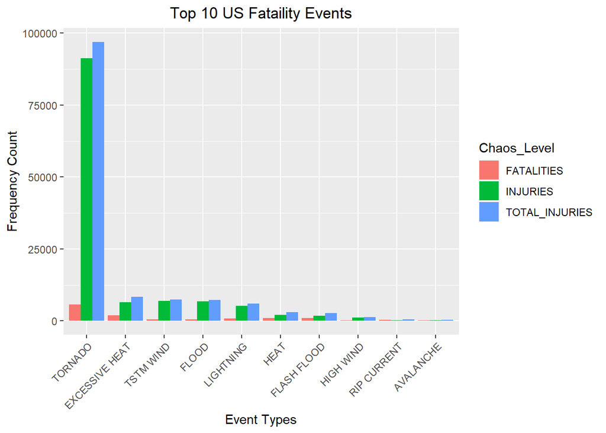

```r
# Generate Chart
InjuryChart <- ggplot(chaos, aes(x = reorder(EVTYPE, -value), y = value))

# Plot as Bar Chart
InjuryChart = InjuryChart + geom_bar(stat = "identity", aes(fill = Chaos_Level), position ="dodge")

# Format y axis scale and setup y-axis label
InjuryChart = InjuryChart + ylab("Frequency Count")

# Set x-axis label
InjuryChart = InjuryChart + xlab("Event Types")

# Rotate x-axis tick labels
InjuryChart = InjuryChart + theme(axis.text.x = element_text(angle=45, hjust=1))

# Set and centerlized the chart title
InjuryChart = InjuryChart + ggtitle("Top 10 US Fataility Events") + theme(plot.title = element_text(hjust = 0.5))
InjuryChart
```

### 3.2: Events which caused the Greatest Economic Consequences

Melt the data.table for bar graph format with sub levels

```r
eimpact <- melt(Cost_Total, id.vars="EVTYPE", variable.name = "Damage_Type")
head(eimpact, 5)
```

```
##               EVTYPE Damage_Type        value
## 1:             FLOOD   Cost_Prop 144657709807
## 2: HURRICANE/TYPHOON   Cost_Prop  69305840000
## 3:           TORNADO   Cost_Prop  56947380677
## 4:       STORM SURGE   Cost_Prop  43323536000
## 5:              HAIL   Cost_Prop  15735267513
```

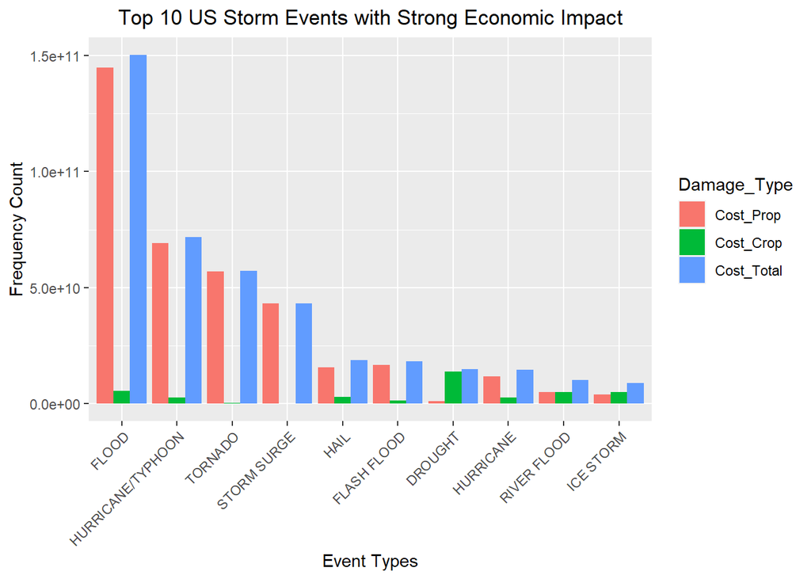

```r
# Generate Chart
econChart <- ggplot(eimpact, aes(x = reorder(EVTYPE, -value), y = value))

# Plot as Bar Chart
econChart = econChart + geom_bar(stat = "identity", aes(fill = Damage_Type), position ="dodge")

# Format y axis scale and setup y-axis label
econChart = econChart + ylab("Frequency Count")

# Set x-axis label
econChart = econChart + xlab("Event Types")

# Rotate x-axis tick labels
econChart = econChart + theme(axis.text.x = element_text(angle=45, hjust=1))

# Set and centerlized the chart title
econChart = econChart + ggtitle("Top 10 US Storm Events with Strong Economic Impact") + theme(plot.title = element_text(hjust = 0.5))
econChart
```